# HW1

## 1

```r
library(tidyverse)
students <- read.table("students.txt", header = TRUE)
students
```

```
##     Student Gender Smoke Marijuan DrivDrnk   GPA PartyNum DaysBeer StudyHrs
## 1         1 female    No      Yes      Yes 3.400        4        6        7
## 2         2 female    No       No       No 3.450        4        0       20
## 3         3   male    No       No      Yes 3.890        9        4       30
## 4         4 female    No       No       No 3.750        6        3       12
## 5         5   male   Yes      Yes      Yes 2.300       10       15       14
## 6         6 female   Yes      Yes       No 2.800        2        5       10
## 7         7   male    No       No       No 2.700        8        0       15
## 8         8 female    No       No       No 2.600        5        5       25
## 9         9 female    No      Yes      Yes 1.870       16       20        6
## 10       10 female    No       No       No 2.740        0        2       10
## 11       11 female    No       No      Yes 2.000        6       10        8
## 12       12 female    No       No       No 3.000        2        4       20
## 13       13   male    No      Yes       No 3.200        1        3        2
## 14       14 female    No      Yes      Yes 3.000       10       12       10
```

[output cut: 235 more lines]

```r
students <- select(students, -Student)
students
```

```
##     Gender Smoke Marijuan DrivDrnk   GPA PartyNum DaysBeer StudyHrs
## 1   female    No      Yes      Yes 3.400        4        6        7
## 2   female    No       No       No 3.450        4        0       20
## 3     male    No       No      Yes 3.890        9        4       30
## 4   female    No       No       No 3.750        6        3       12
## 5     male   Yes      Yes      Yes 2.300       10       15       14
## 6   female   Yes      Yes       No 2.800        2        5       10
## 7     male    No       No       No 2.700        8        0       15
## 8   female    No       No       No 2.600        5        5       25
## 9   female    No      Yes      Yes 1.870       16       20        6
## 10  female    No       No       No 2.740        0        2       10
## 11  female    No       No      Yes 2.000        6       10        8
## 12  female    No       No       No 3.000        2        4       20
## 13    male    No      Yes       No 3.200        1        3        2
## 14  female    No      Yes      Yes 3.000       10       12       10
```

[output cut: 235 more lines]

2. How many students?

```r
nrow(students)
```

```
## [1] 249
```

```r
nrow(students[!complete.cases(students),])
```

```
## [1] 12
```

```r
students <- students[complete.cases(students),]
students
```

```
##     Gender Smoke Marijuan DrivDrnk   GPA PartyNum DaysBeer StudyHrs
## 1   female    No      Yes      Yes 3.400        4        6        7
## 2   female    No       No       No 3.450        4        0       20
## 3     male    No       No      Yes 3.890        9        4       30
## 4   female    No       No       No 3.750        6        3       12
## 5     male   Yes      Yes      Yes 2.300       10       15       14
## 6   female   Yes      Yes       No 2.800        2        5       10
## 7     male    No       No       No 2.700        8        0       15
## 8   female    No       No       No 2.600        5        5       25
## 9   female    No      Yes      Yes 1.870       16       20        6
## 10  female    No       No       No 2.740        0        2       10
## 11  female    No       No      Yes 2.000        6       10        8
## 12  female    No       No       No 3.000        2        4       20
## 13    male    No      Yes       No 3.200        1        3        2
## 14  female    No      Yes      Yes 3.000       10       12       10
```

[output cut: 223 more lines]

4. Report median values of the numeric values.

```r
students %>%
  summarize(median_GPA = median(GPA), median_studyhrs= median(StudyHrs))
```

```
##   median_GPA median_studyhrs
## 1        3.2              12
```

5. Compare the mean, standard deviation, and median StudyHrs between female and male students. Based on these values, comment on what you can glean about time spent studying between female and male students.

```r
students %>%
  group_by(Gender) %>%
  summarize(mean(StudyHrs), sd(StudyHrs), median(StudyHrs))
```

```
## # A tibble: 2 × 4
##   Gender `mean(StudyHrs)` `sd(StudyHrs)` `median(StudyHrs)`
##   <fct>             <dbl>          <dbl>              <dbl>
## 1 female             15.3           9.06               12.5
## 2 male               14.7          10.3                12
```

6. Create a new variable called PartyAnimal, which takes on the value “yes” if PartyNum the student parties a lot (more than 8 days a month), and “no” otherwise.

```r
students <- students %>%
  mutate(PartyAnimal = ifelse(PartyNum > 8, "yes", "no"))
students
```

```
##     Gender Smoke Marijuan DrivDrnk   GPA PartyNum DaysBeer StudyHrs PartyAnimal
## 1   female    No      Yes      Yes 3.400        4        6        7          no
## 2   female    No       No       No 3.450        4        0       20          no
## 3     male    No       No      Yes 3.890        9        4       30         yes
## 4   female    No       No       No 3.750        6        3       12          no
## 5     male   Yes      Yes      Yes 2.300       10       15       14         yes
## 6   female   Yes      Yes       No 2.800        2        5       10          no
## 7     male    No       No       No 2.700        8        0       15          no
## 8   female    No       No       No 2.600        5        5       25          no
## 9   female    No      Yes      Yes 1.870       16       20        6         yes
## 10  female    No       No       No 2.740        0        2       10          no
## 11  female    No       No      Yes 2.000        6       10        8          no
## 12  female    No       No       No 3.000        2        4       20          no
## 13    male    No      Yes       No 3.200        1        3        2          no
## 14  female    No      Yes      Yes 3.000       10       12       10         yes
```

[output cut: 223 more lines]

7. Create a new variable called GPA.cat, which takes on the following values • “low” if GPA is less than 3.0 • “moderate” if GPA is less than 3.5 and at least 3.0 • “high” if GPA is at least 3.5

```r
students <- students %>%
  mutate(GPA.cat = cut(GPA, breaks = c(-Inf, 3.0, 3.5, Inf), right = FALSE,
                                 labels = c("low", "moderate", "high")))
students
```

```
##     Gender Smoke Marijuan DrivDrnk   GPA PartyNum DaysBeer StudyHrs PartyAnimal
## 1   female    No      Yes      Yes 3.400        4        6        7          no
## 2   female    No       No       No 3.450        4        0       20          no
## 3     male    No       No      Yes 3.890        9        4       30         yes
## 4   female    No       No       No 3.750        6        3       12          no
## 5     male   Yes      Yes      Yes 2.300       10       15       14         yes
## 6   female   Yes      Yes       No 2.800        2        5       10          no
## 7     male    No       No       No 2.700        8        0       15          no
## 8   female    No       No       No 2.600        5        5       25          no
## 9   female    No      Yes      Yes 1.870       16       20        6         yes
## 10  female    No       No       No 2.740        0        2       10          no
## 11  female    No       No      Yes 2.000        6       10        8          no
## 12  female    No       No       No 3.000        2        4       20          no
## 13    male    No      Yes       No 3.200        1        3        2          no
## 14  female    No      Yes      Yes 3.000       10       12       10         yes
```

[output cut: 461 more lines]

8. Suppose we want to focus on students who have low GPAs (below 3.0), party a lot (more than 8 days a month), and study little (less than 15 hours a week). Create a data frame that contains these students. How many such students are there?

```r
students %>%
  filter((GPA < 3.0) & (StudyHrs < 15) & (PartyNum > 8))
```

```
##    Gender Smoke Marijuan DrivDrnk  GPA PartyNum DaysBeer StudyHrs PartyAnimal
## 1    male   Yes      Yes      Yes 2.30       10       15       14         yes
## 2  female    No      Yes      Yes 1.87       16       20        6         yes
## 3  female    No      Yes      Yes 2.70        9        8        9         yes
## 4  female   Yes      Yes      Yes 2.33       10       20        5         yes
## 5  female   Yes      Yes      Yes 2.87        9       15        6         yes
## 6  female    No      Yes      Yes 2.70       14       12       14         yes
## 7  female    No       No       No 2.65        9        9        6         yes
## 8  female   Yes      Yes      Yes 2.80       10       20        6         yes
## 9    male    No      Yes       No 2.86       12       20        8         yes
## 10   male    No      Yes      Yes 2.75       20       20       10         yes
## 11   male    No      Yes      Yes 2.21       15       20        5         yes
## 12   male    No       No       No 2.58       15       10        9         yes
## 13 female   Yes       No      Yes 2.90       10        0        8         yes
## 14   male   Yes      Yes      Yes 2.65       12       12       10         yes
```

[output cut: 45 more lines]

10. Produce a bar chart that summarizes the number of students in each level of GPA.cat. Be sure to add appropriate labels and titles so that the bar chart conveys its message clearly to the reader. Be sure to remove the bar corresponding to the missing values.

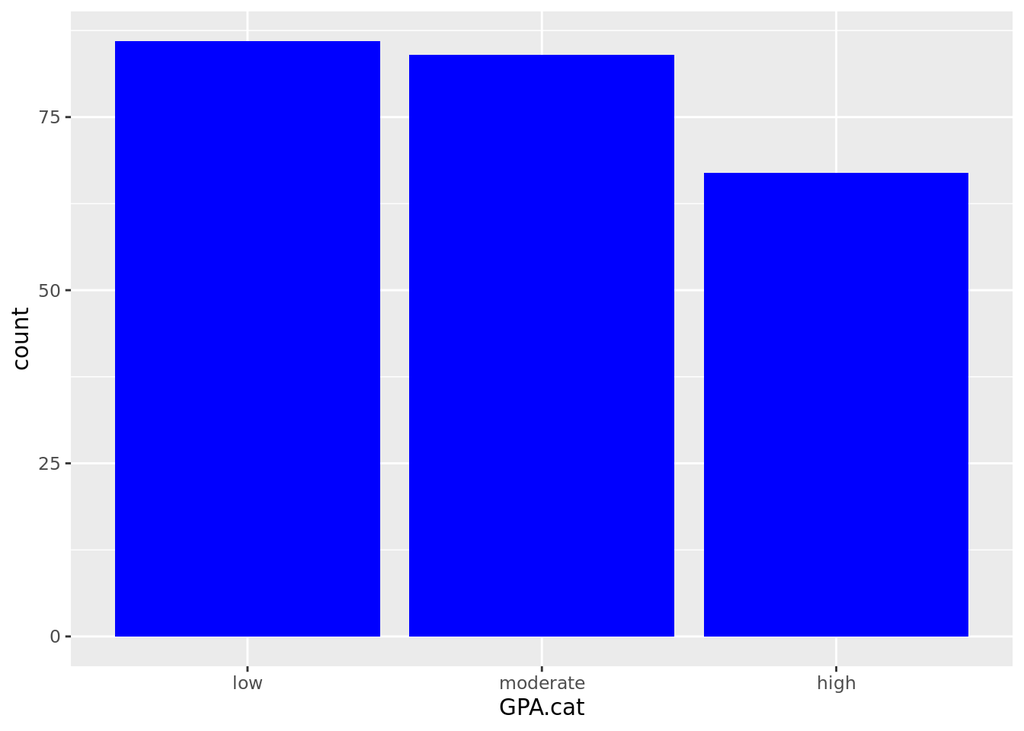

```r
ggplot(students, aes(x = GPA.cat)) +
  geom_bar(xlab = "GPA levels", ylab = "Observations", title = "Number of Students Across GPA Levels", fill = "blue")
```

11. Create a similar bar chart as you did in part 1j, but with proportions instead of counts. Be sure to remove the bar corresponding to the missing values.

```r
new_students <- students %>%
  group_by(GPA.cat) %>%
  summarize(Counts=n()) %>%
  mutate(Percent=Counts/nrow(students)) %>%
  select(-Counts)
new_students
```

```
## # A tibble: 3 × 2
##   GPA.cat  Percent
##   <fct>      <dbl>
## 1 low        0.363
## 2 moderate   0.354
## 3 high       0.283
```

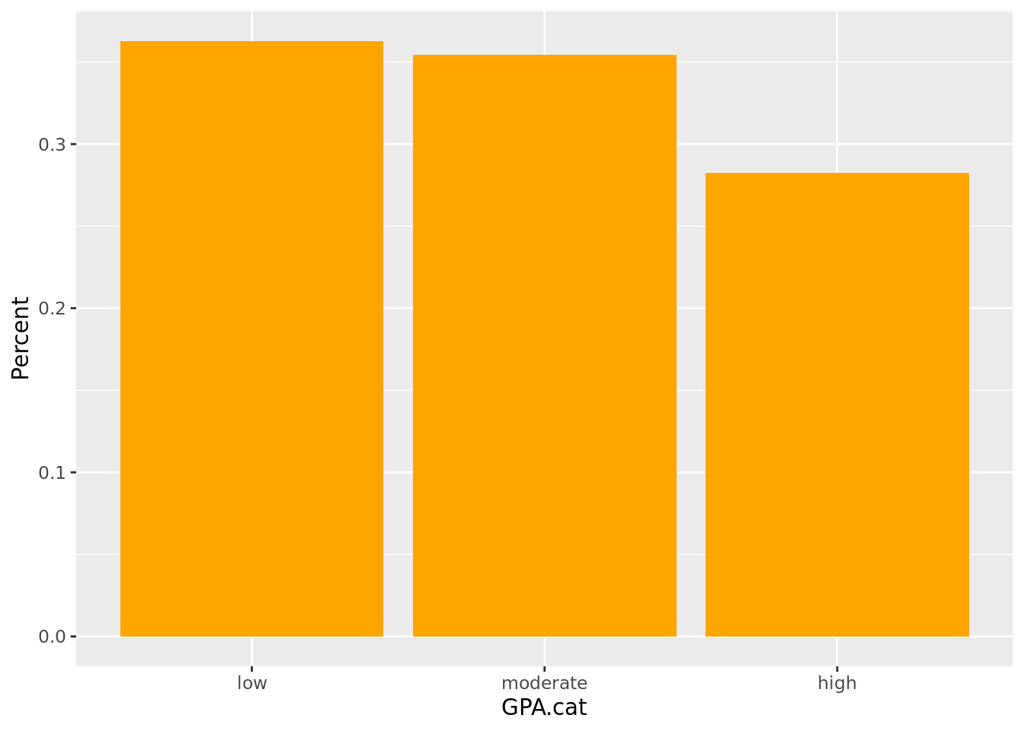

```r
ggplot(new_students, aes(x = GPA.cat, y = Percent)) +
  geom_bar(stat ="identity", fill = "orange")
```

12. Produce a frequency table for the number of female and male students and the GPA category

```r
table(students$GPA.cat, students$Gender)
```

```
##
##            female male
##   low          40   46
##   moderate     51   33
##   high         45   22
```

13. Produce a table for the percentage of GPA category for each gender. For the percentages, round to 2 decimal places. Comment on the relationship between gender and GPA category

```r
x <- round(table(students$GPA.cat, students$Gender) %>% prop.table(),2)
x
```

```
##
##            female male
##   low        0.17 0.19
##   moderate   0.22 0.14
##   high       0.19 0.09
```

14. Create a bar chart to explore the proportion of GPA categories for female and male students. Be sure to remove the bar corresponding to the missing values.

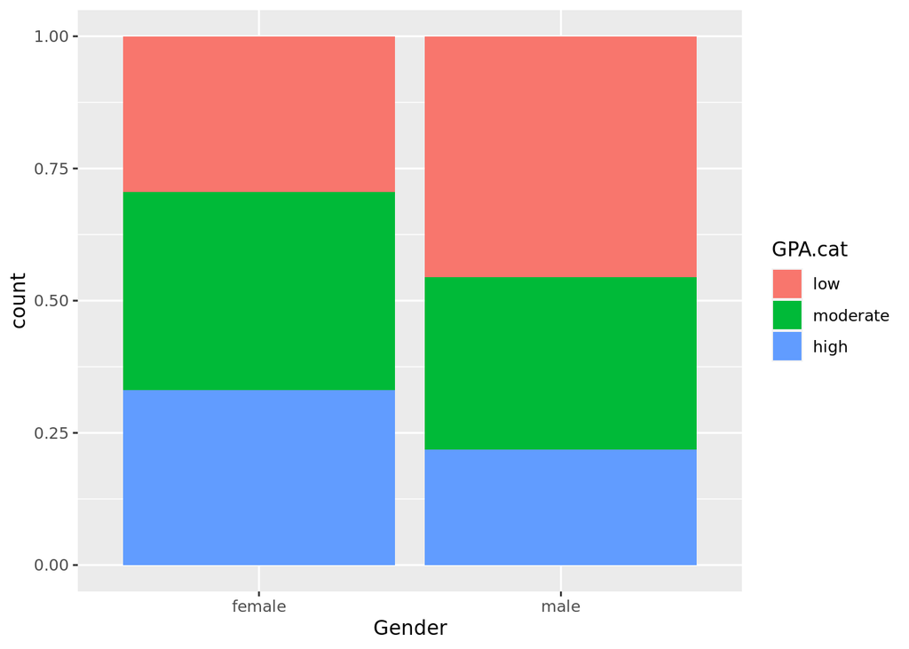

```r
ggplot(students,aes(x=Gender, fill=GPA.cat)) +
  geom_bar(position = "fill")
```

15. Create a similar bar chart similar to the bar chart in part 1n, but split by smoking status. Comment on this bar chart.

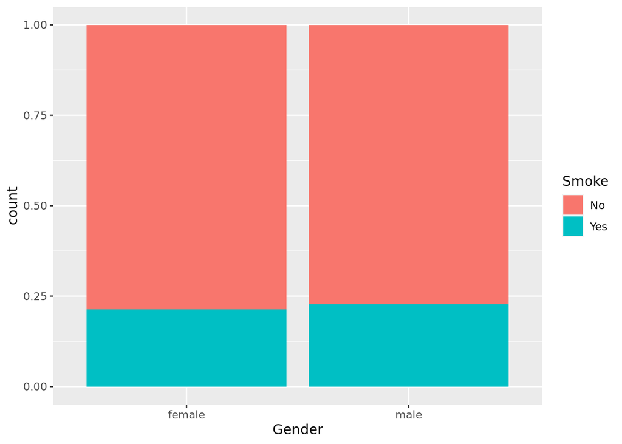

```r
ggplot(students,aes(x=Gender, fill=Smoke)) +
  geom_bar(position = "fill")
```

16. Create a scatterplot of GPA against the amount of hours spent studying a week. How would you describe the relationship between GPA and amount of time spent studying?

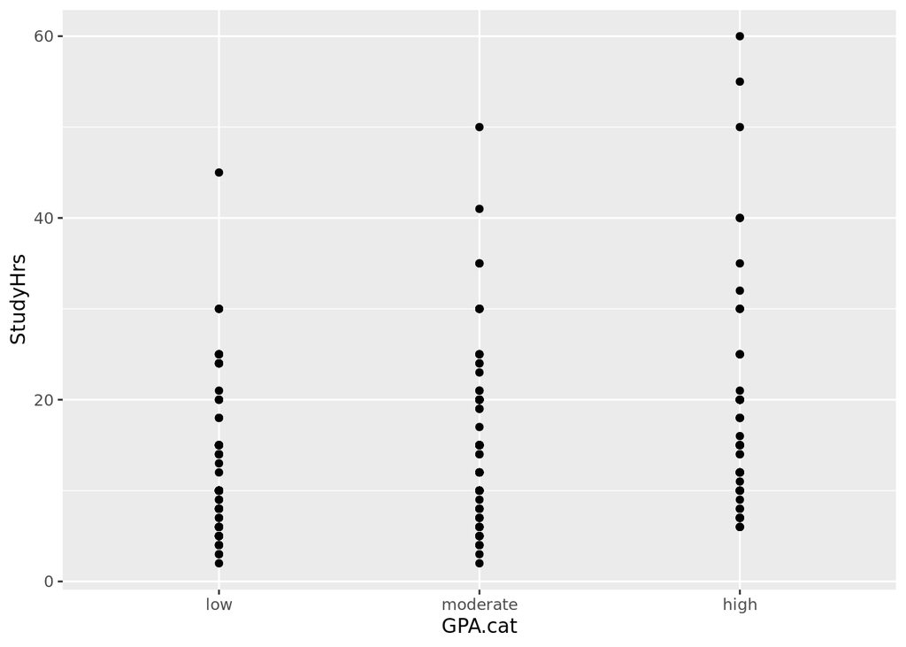

```r
ggplot(students, aes(x= GPA.cat, y = StudyHrs)) +
  geom_point()
```

17. Edit the scatterplot from part 1p to include information about the number of days the student parties in a month.

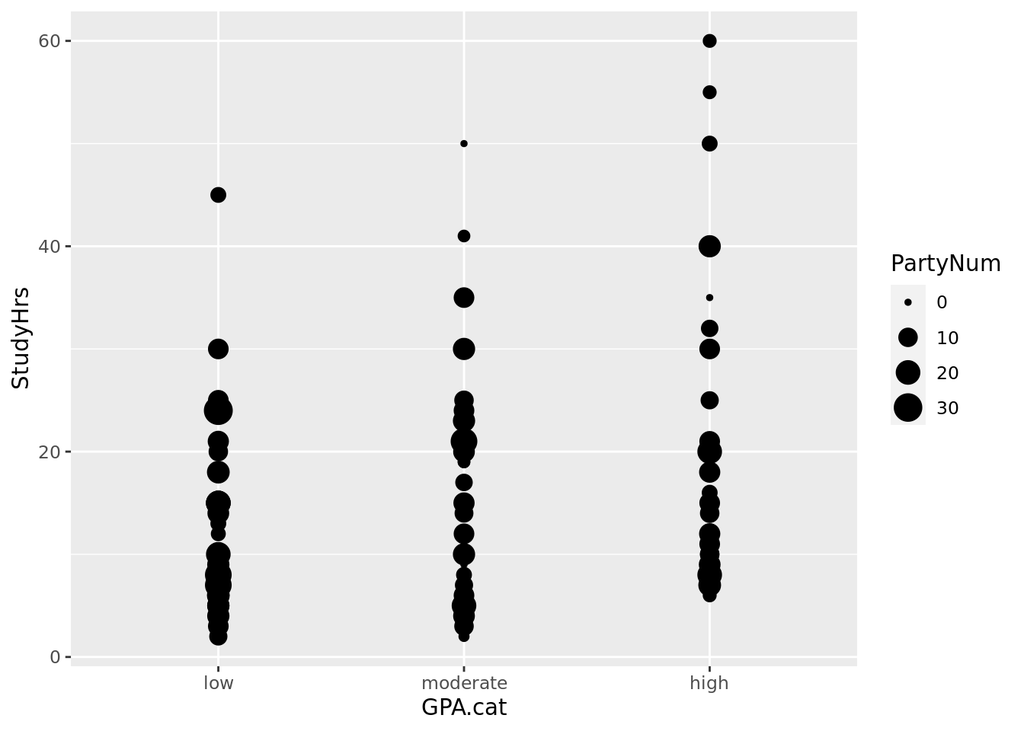

```r
ggplot(students, aes(x= GPA.cat, y = StudyHrs, size = PartyNum)) +
  geom_point()
```

18. Edit the scatterplot from part 1q to include information about whether the student smokes or not.

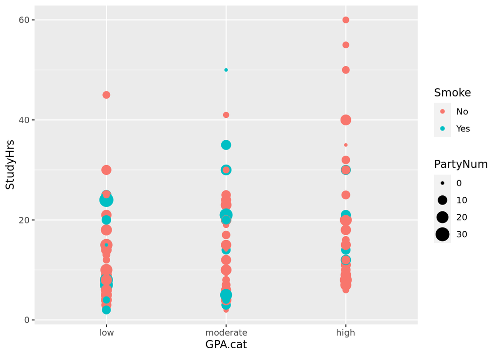

```r
ggplot(students, aes(x= GPA.cat, y = StudyHrs, size = PartyNum, color = Smoke)) +
  geom_point()
```

## 4. We will look at a data set concerning adult penguins near Palmer station, Antarctica. The data set, penguins comes from the palmerpenguins package. Be sure to install and load the palmerpenguins package. I recommend reading the documentation of this data set by typing ?penguins We will explore the relationship between the response variable body mass (in grams), body_mass_g, and the predictor length of the flippers (in mm), flipper_length_mm.

```r
#install.packages("palmerpenguins")
```

```r
library(palmerpenguins)
penguins <- penguins[complete.cases(penguins),]
penguins
```

```
## # A tibble: 333 × 8
##    species island    bill_length_mm bill_depth_mm flipper_length_mm body_mass_g
##    <fct>   <fct>              <dbl>         <dbl>             <int>       <int>
##  1 Adelie  Torgersen           39.1          18.7               181        3750
##  2 Adelie  Torgersen           39.5          17.4               186        3800
##  3 Adelie  Torgersen           40.3          18                 195        3250
##  4 Adelie  Torgersen           36.7          19.3               193        3450
##  5 Adelie  Torgersen           39.3          20.6               190        3650
##  6 Adelie  Torgersen           38.9          17.8               181        3625
##  7 Adelie  Torgersen           39.2          19.6               195        4675
##  8 Adelie  Torgersen           41.1          17.6               182        3200
##  9 Adelie  Torgersen           38.6          21.2               191        3800
## 10 Adelie  Torgersen           34.6          21.1               198        4400
## # … with 323 more rows, and 2 more variables: sex <fct>, year <int>
```

1. Produce a scatterplot of the two variables. How would you describe the relationship between the two variables? Be sure to label the axes and give an appropriate title. Based on the appearance of the plot, does a simple linear regression appear reasonable for the data?

There seems to be a linear relationship between flipper length and body mass.

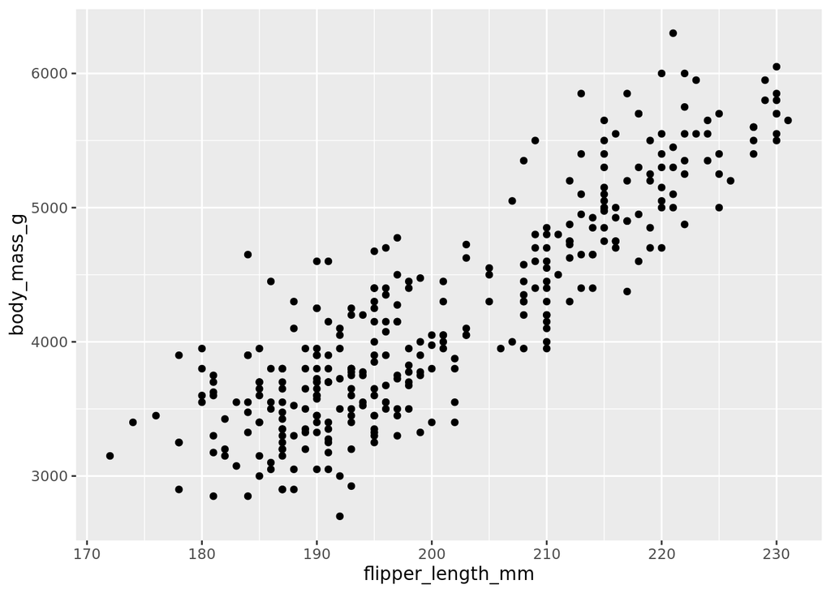

```r
ggplot(penguins, aes(x = flipper_length_mm, y = body_mass_g)) +
  geom_point(xlab = "Flipper Length (in mm)", ylab = "Body Mass (in gram)", title = "A Scatterplot of Flipper Length vs Body Mass")
```

2. Produce a similar scatterplot, but with different colored plots for each species. How does this scatterplot influence your answer to the previous part?

There seems to be linear relationship between flipper length and body mass across all species. This scatterplot does not influence my answer to the previous part.

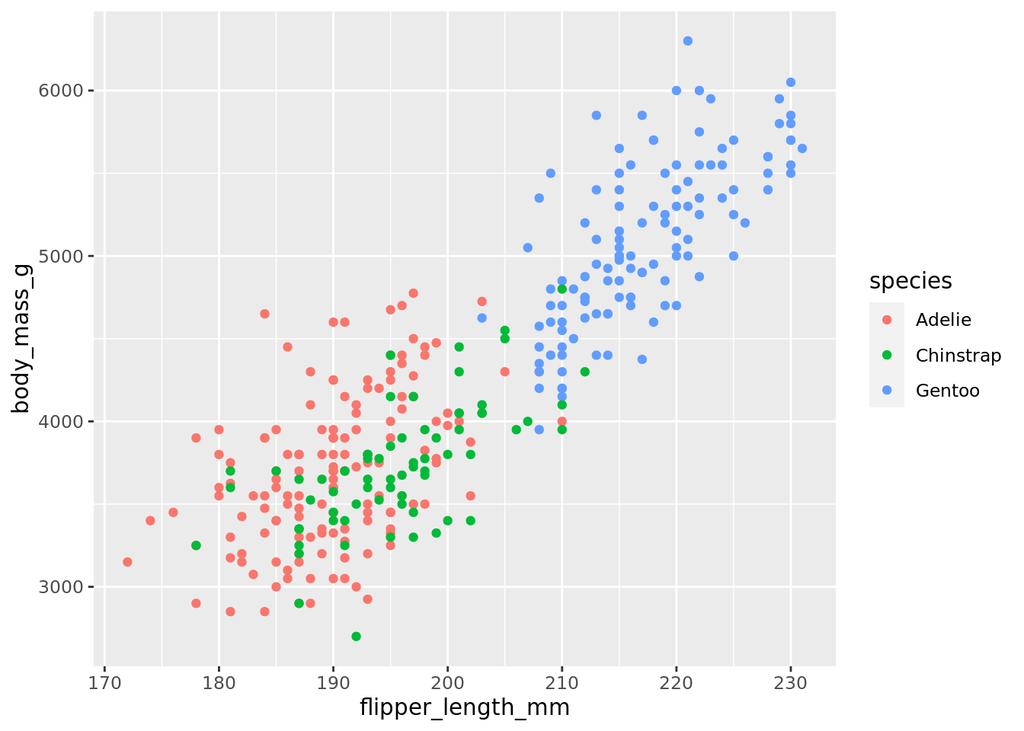

```r
ggplot(penguins, aes(x = flipper_length_mm, y = body_mass_g, color = species)) +
  geom_point(xlab = "Flipper Length (in mm)", ylab = "Body Mass (in gram)", title = "A Scatterplot of Flipper Length vs Body Mass across Species")
```

3. Regardless of your answer to the previous part, produce a scatterplot of body mass and flipper length for Gentoo penguins. Based on the appearance of the plot, does a simple linear regression appear reasonable for the data?

YES. There also seems to be a reasonable linear relationship between flipper length and body mass for Gentoo penguins.

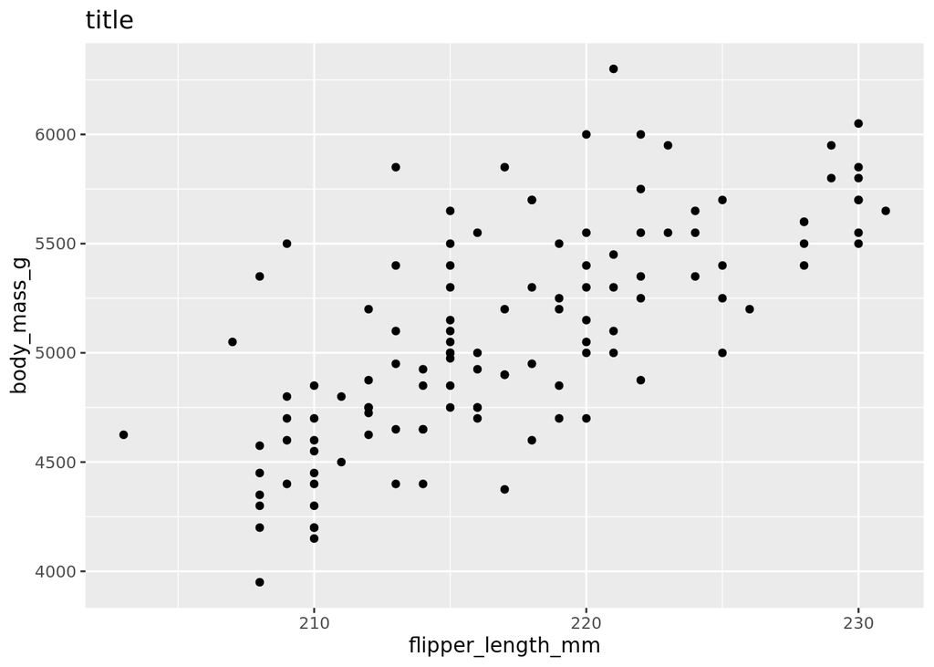

```r
gentoo <- penguins %>%
  filter(species == "Gentoo")

ggplot(gentoo, aes(x = flipper_length_mm, y = body_mass_g, xlab = "Flipper Length (in mm)", ylab = "Body Mass (in gram)", title = "A Scatterplot of Flipper Length vs Body Mass of Gentoo penguins")) +
  geom_point()
```

4. What is the correlation between body mass and flipper length for Gentoo penguins. Interpret this correlation contextually. How reliable is this interpretation? For the rest of the questions, assume the assumptions to perform linear regression on Gentoo penguins are met.

For Gentoo penguins, the correlationship between flipper length and body mass is 0.7113053, which is pretty high. This means flipper length and body mass is in proportional relationship.

```r
cor(gentoo$flipper_length_mm, gentoo$body_mass_g)
```

```
## [1] 0.7113053
```

5. Use the lm() function to fit a linear regression for body mass and flipper length for Gentoo penguins. Write out the estimated linear regression equation.

[output not shown]

```r
lm(body_mass_g ~ flipper_length_mm, data = gentoo)
```

```
##
## Call:
## lm(formula = body_mass_g ~ flipper_length_mm, data = gentoo)
##
## Coefficients:
##       (Intercept)  flipper_length_mm
##          -6674.20              54.17
```

6. Interpret the estimated slope contextually.
7. Does the estimated intercept make sense contextually?
8. Report the value of R2 from this linear regression, and interpret its value contextually
9. What is the estimated value for the standard deviation of the error terms for this regression model, ˆσ?
10. For a Gentoo penguin which has a flipper length of 220mm, what is its predicted body mass in grams?
11. Produce the ANOVA table for this linear regression. Using only this table, calculate the value of R2.
12. What are the null and alternative hypotheses for the ANOVA F test?
13. Explain how the F statistic of 118.01 is found.
14. Write an appropriate conclusion for the ANOVA F test for this simple linear regression model.
15. Report the 95% confidence interval for the change in the predicted body mass (in grams) when flipper length increases by 1mm.
16. Are your results from parts 4n and 4o consistent? Briefly explain.
17. Estimate the mean body mass (in grams) for Gentoo penguins with flipper lengths of 200mm. Also report the 95% confidence interval for the mean body mass (in grams) for Gentoo penguins with flipper lengths of 200mm.
18. Report the 95% prediction interval for the body mass (in grams) of a Gentoo penguin with flipper length of 200mm.
19. A researcher hypothesizes that for Gentoo penguins, the predicted body mass increases by more than 50 g for each additional mm in flipper length. Conduct an appropriate hypothesis test. What is the null and alternative hypotheses, test statistic, and conclusion?